# Matplotlib (Python Plotting Library)

Human minds are more adaptive for the visual representation of data rather than textual data. We can easily understand things when they are visualized. It is better to represent the data through the graph where we can analyze the data more efficiently and make the specific decision according to data analysis.

**TO INstall Matplotlib** pip install matplotlib

```python
import matplotlib.pyplot as plt
from matplotlib import style
import numpy as np
import random
```

## Creating different types of graph

### 1. Line graph

The pyplot.plot() or plt.plot() is a method of matplotlib pyplot module use to plot the line.

**Syntax: plt.plot(*args, scalex=True, scaley=True, data=None,** kwargs)**

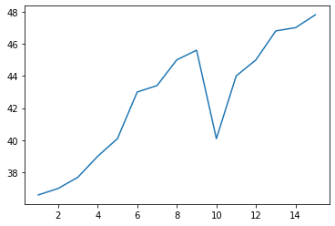

```python
# Suppose we have the dataframe
days = [1,2,3,4,5,6,7,8,9,10,11,12,13,14,15]
temperature = [36.6, 37, 37.7,39,40.1,43,43.4,45,45.6,40.1,44,45,46.8,47,47.8]

# Let's plot first to see the graph
plt.plot(days, temperature) # Assigned the varible values
plt.show()  # Showed the result
```

```
<function matplotlib.pyplot.show>
```

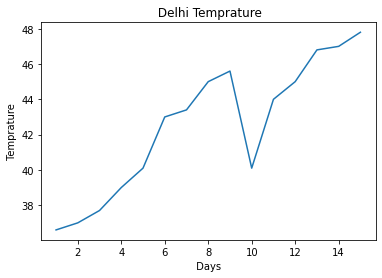

```python
# To show the axis of the graph and legeds means labels
plt.plot(days, temperature)
plt.title(" Delhi Temprature")
plt.xlabel(" Days ")
plt.ylabel(" Temprature ")
plt.show
```

```
<function matplotlib.pyplot.show>
```

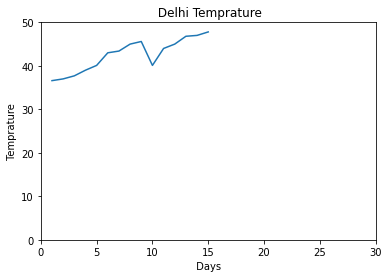

```python
# If we have to set the axis value to represent graph from any values along with color
plt.plot(days, temperature )
plt.axis([0,30, 0,50])
plt.title(" Delhi Temprature")
plt.xlabel(" Days ")
plt.ylabel(" Temprature ")
plt.show
```

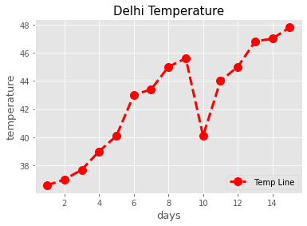

```python
# If we want to make own style to represent the graph also we can change background with ggplot

style.use("ggplot") # give ggplot parameter value to use() method
plt.plot(days, temperature, color= 'r', marker = 'o', linestyle='--', linewidth=3, markersize= 10 , label = " Temp Line")
plt.title("Delhi Temperature", fontsize=15)
plt.xlabel("days",fontsize=13)
plt.ylabel("temperature",fontsize=13)
plt.legend(loc = 4)
plt.show()
```

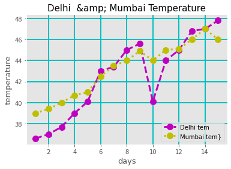

```python
# If want to plot Multiple Lines Plot
days = [1,2,3,4,5,6,7,8,9,10,11,12,13,14,15]
delhi_tem = [36.6, 37, 37.7,39,40.1,43,43.4,45,45.6,40.1,44,45,46.8,47,47.8]
mumbai_tem = [39,39.4,40,40.7,41,42.5,43.5,44,44.9,44,45,45.1,46,47,46]

plt.plot(days, delhi_tem, "mo--", linewidth = 3,
        markersize = 10, label = "Delhi tem")  #mo-- (Combination of = color, marker and linestyle)

plt.plot(days, mumbai_tem, "yo:", linewidth = 3,
        markersize = 10, label = "Mumbai tem}")

plt.title("Delhi  &amp; Mumbai Temperature", fontsize=15)
plt.xlabel("days",fontsize=13)
plt.ylabel("temperature",fontsize=13)
plt.legend(loc = 4)
plt.grid(color='c', linestyle='-', linewidth=2) # grid with parameter
plt.show()
```

1. ## Histogram

Matplotlib histogram is a representation of numeric data in the form of a rectangle bar. Each bar shows some data, which belong to different categories. To plot histogram using python matplotlib library need plt.hist() method.

**Syntax: plt.hist( x, bins=None, range=None, density=None, weights=None, cumulative=False, bottom=None, histtype=’bar’, align=’mid’, orientation=’vertical’, rwidth=None, log=False, color=None, label=None, stacked=False, normed=None, *, data=None,**kwargs, )**

```python
# Let's take random values
ml_students_age = np.random.randint(18,45, (100))
py_students_age = np.random.randint(15,40, (100))
print(ml_students_age)
print(py_students_age)
```

```
[23 39 22 26 32 26 23 23 28 44 42 33 19 24 30 25 44 32 18 18 31 35 31 37
 19 41 38 19 23 31 19 34 35 18 42 43 42 39 38 26 22 32 23 27 28 31 35 27
 43 32 28 24 39 39 38 42 21 31 33 23 18 41 44 19 31 38 29 43 27 29 44 22
 30 29 31 40 27 33 27 35 35 36 22 29 37 26 18 18 44 22 18 30 30 36 22 41
 38 19 32 43]
[27 25 33 24 18 27 16 33 19 32 18 38 31 18 32 24 22 38 30 15 21 34 29 21
 39 26 34 24 30 34 37 16 28 16 17 21 38 33 32 21 29 25 19 36 20 31 34 16
 18 28 20 15 23 15 36 26 33 23 35 31 38 32 30 36 21 22 32 20 22 17 23 31
 15 16 18 29 20 18 23 17 23 16 20 19 37 35 24 32 29 33 28 26 23 25 36 16
 38 36 28 35]
```

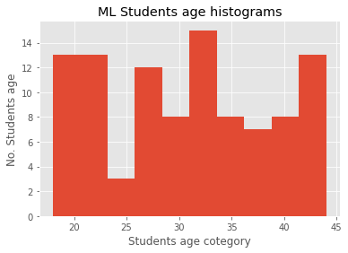

```python
# Let's plot the histogram for the student
plt.hist(ml_students_age)

plt.title("ML Students age histograms")
plt.xlabel("Students age cotegory")
plt.ylabel("No. Students age")
plt.show()
```

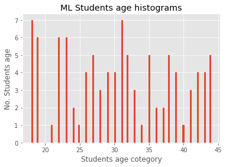

```python
# Let take the data into bins

plt.hist(ml_students_age, bins=100) # Bins is range(limitation) of value
plt.title("ML Students age histograms")
plt.xlabel("Students age cotegory")
plt.ylabel("No. Students age")
plt.show()
```

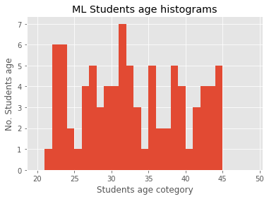

```python
# Let take the data into range bins

plt.hist(ml_students_age, bins=range(20, 50)) # Bins is range(limitation) of value
plt.title("ML Students age histograms")
plt.xlabel("Students age cotegory")
plt.ylabel("No. Students age")
plt.show()
```

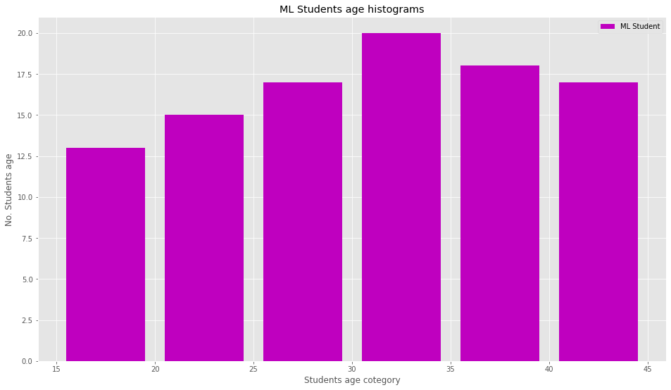

```python
bins = [15,20,25,30,35,40,45] # category of ML students age on x axis
plt.figure(figsize = (16,9)) # size of histogram in 16:9 format


plt.hist(ml_students_age, bins, rwidth=0.8, histtype = "bar",
         orientation='vertical', color = "m", label = "ML Student")

plt.title("ML Students age histograms")
plt.xlabel("Students age cotegory")
plt.ylabel("No. Students age")
plt.legend()
plt.show()
```

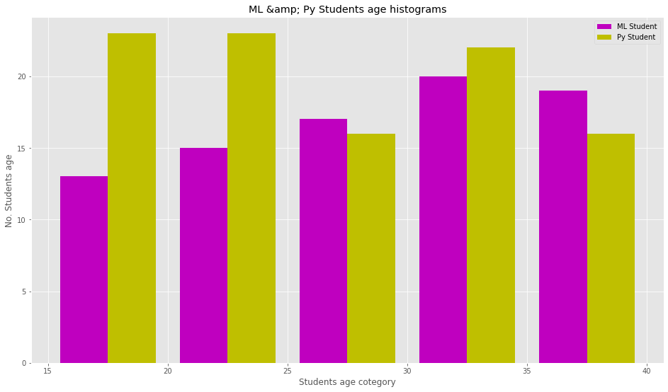

```python
# Plotting two Histogram Using Matplotlib with parameters
bins =range(15, 45, 5)
style.use('ggplot') # return grid
plt.figure(figsize=(16,9))
plt.hist([ml_students_age, py_students_age],bins, rwidth=0.8, orientation='vertical',
         color=['m','y'], label=["ML Student", "Py Student"])
plt.title("ML &amp; Py Students age histograms")
plt.xlabel("Students age cotegory")
plt.ylabel("No. Students age")
plt.legend()
plt.show()
```

1. ## Bar Chart To visualize value associated with categorical data in the bar format use matplotlib bar chart plt.bar() or plt.barh() methods.

Syntax: plt.bar( x, height, width=0.8, bottom=None, *, align=’center’, data=None, **kwargs, )

```
<BarContainer object of 5 artists>
```

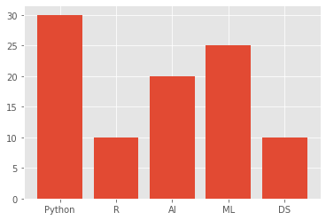

```python
# suppose we have the data of Indian Artificial Intelligence Production Class
classes = ["Python", "R", "AI", "ML", "DS"]
class1_students = [30, 10, 20, 25, 10] # out of 100 student in each class
class2_students = [40, 5, 20, 20, 10]
class3_students = [35, 5, 30, 15, 15]

plt.bar(classes, class1_students)
```

```
<BarContainer object of 5 artists>
```

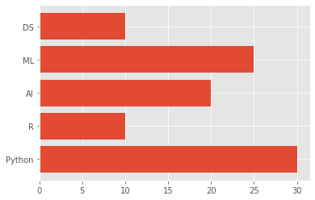

```python
# To plot horizontal
plt.barh(classes, class1_students)
```

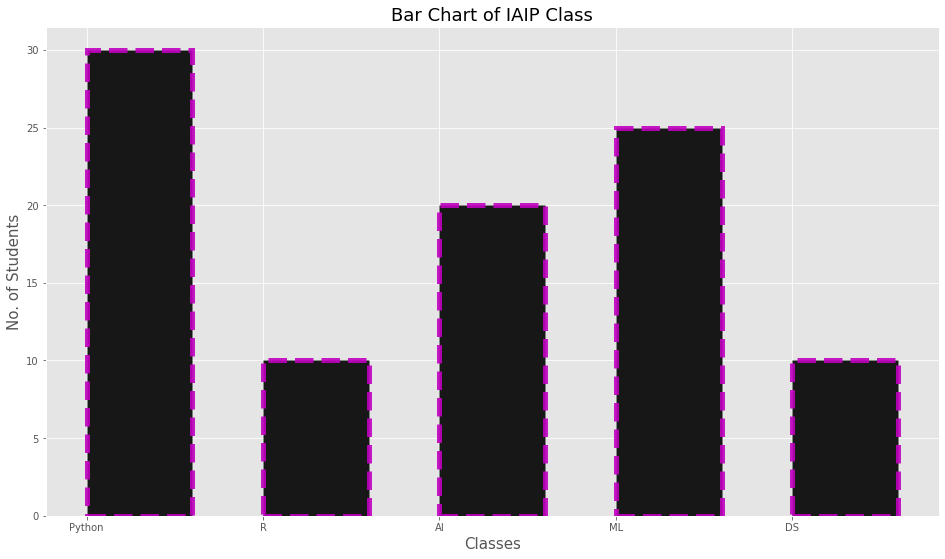

```python
# Decorating bar chart using multiple functions.
plt.figure(figsize=(16,9))
plt.bar(classes, class1_students, width = 0.6, align = "edge", color = "k",
       edgecolor = "m", linewidth = 5, alpha = 0.9, linestyle = "--",
       label =" Class 1 Students") #visible=False

plt.title("Bar Chart of IAIP Class", fontsize = 18)
plt.xlabel("Classes",fontsize = 15)
plt.ylabel("No. of Students", fontsize = 15)
plt.show()
```

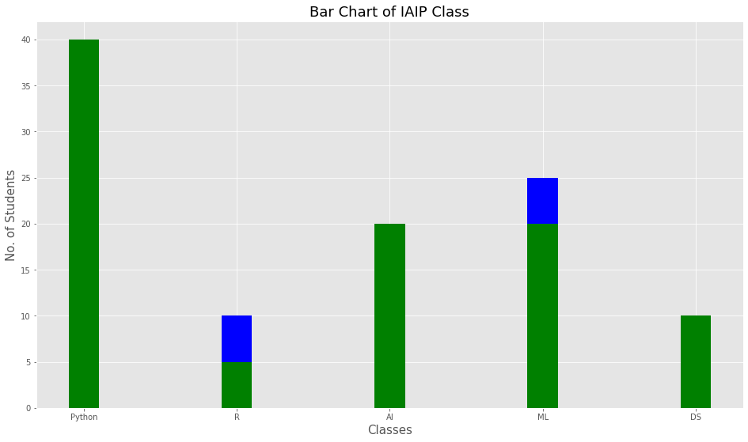

```python
# Decorating bar chart using multiple functions.
plt.figure(figsize=(16,9))

plt.bar(classes, class1_students, width = 0.2, color = "b",
        label =" Class 1 Students") #visible=False

plt.bar(classes, class2_students, width = 0.2, color = "g",
        label =" Class 2 Students")

plt.title("Bar Chart of IAIP Class", fontsize = 18)
plt.xlabel("Classes",fontsize = 15)
plt.ylabel("No. of Students", fontsize = 15)
plt.show()
```

The above code not generating two bar charts in one figure but they are overlapping. So use the below code to plot multiple bar charts. In below chart plot three bar charts using three different datasets.

```
[0 1 2 3 4]
```

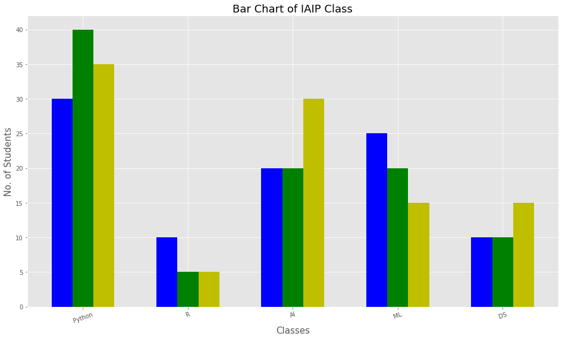

```python
plt.figure(figsize=(16,9))

classes_index = np.arange(len(classes))
print(classes_index)

width = 0.2

plt.bar(classes_index, class1_students, width , color = "b",
        label =" Class 1 Students") #visible=False

plt.bar(classes_index + width, class2_students, width , color = "g",
        label =" Class 2 Students")

plt.bar(classes_index + width + width, class3_students, width , color = "y",
        label =" Class 2 Students")

plt.xticks(classes_index + width, classes, rotation = 20)
plt.title("Bar Chart of IAIP Class", fontsize = 18)
plt.xlabel("Classes",fontsize = 15)
plt.ylabel("No. of Students", fontsize = 15)
plt.show()
```

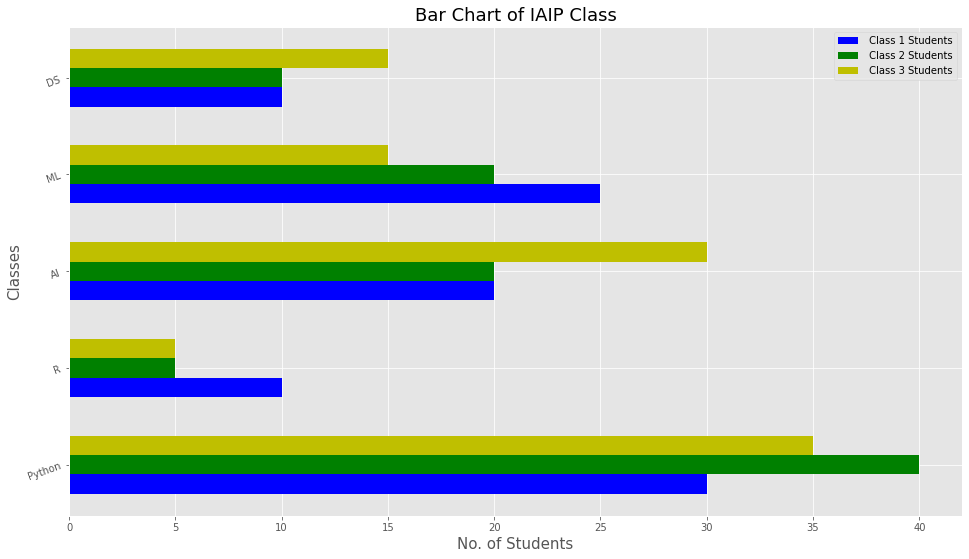

```python
# To plot the horizontal
plt.figure(figsize=(16,9))

classes_index = np.arange(len(classes))

width = 0.2

plt.barh(classes_index, class1_students, width , color = "b",
        label =" Class 1 Students") #visible=False

plt.barh(classes_index + width, class2_students, width , color = "g",
        label =" Class 2 Students")

plt.barh(classes_index + width + width, class3_students, width , color = "y",
        label =" Class 3 Students")

plt.yticks(classes_index + width, classes, rotation = 20)
plt.title("Bar Chart of IAIP Class", fontsize = 18)
plt.ylabel("Classes",fontsize = 15)
plt.xlabel("No. of Students", fontsize = 15)
plt.legend()
plt.show()
```

1. ## Scatter Plot